# Homework 2

Ryan Quon

## Linear Regression

For this lab, we will be working with a data set from the UCI (University of California, Irvine) Machine Learning repository ([see website here](http://archive.ics.uci.edu/ml/datasets/Abalone)). The full data set consists of $4,177$ observations of abalone in Tasmania. (Fun fact: Tasmania supplies about $25\%$ of the yearly world abalone harvest.)

The age of an abalone is typically determined by cutting the shell open and counting the number of rings with a microscope. The purpose of this data set is to determine whether abalone age (**number of rings + 1.5**) can be accurately predicted using other, easier-to-obtain information about the abalone.

The full abalone data set is located in the `\data` subdirectory. Read it into *R* using `read_csv()`. Take a moment to read through the codebook (`abalone_codebook.txt`) and familiarize yourself with the variable definitions.

Make sure you load the `tidyverse` and `tidymodels`!

```r
library(tidyverse)
library(tidymodels)
library(yardstick)
data <- read_csv("C:/Users/ryanc/OneDrive/Desktop/PSTAT131/homework-2/homework-2/data/abalone.csv")
```

### Question 1

Your goal is to predict abalone age, which is calculated as the number of rings plus 1.5. Notice there currently is no `age` variable in the data set. Add `age` to the data set.

Assess and describe the distribution of `age`.

The distribution of age is roughly normally distributed, single peaked but does have a slight right skew. There also appears to be a few outliers in the age variable.

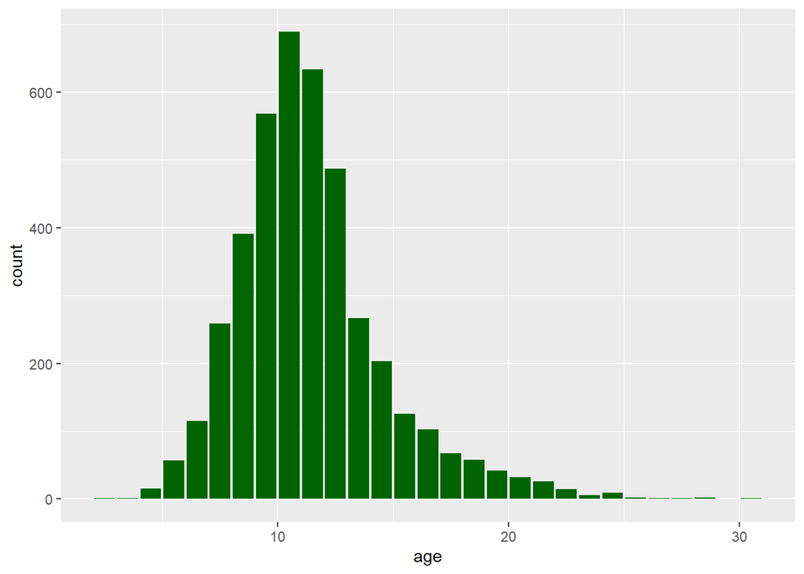

```r
data <- data %>%
  mutate(age = rings + 1.5) %>%
  select(-rings)

ggplot(data, aes(x = age)) + geom_bar(fill = "dark green")
```

### Question 2

Split the abalone data into a training set and a testing set. Use stratified sampling. You should decide on appropriate percentages for splitting the data.

*Remember that you’ll need to set a seed at the beginning of the document to reproduce your results.*

```r
set.seed(265)

data_split <- initial_split(data, prop = 0.80,
                                strata = age)
data_train <- training(data_split)
data_test <- testing(data_split)
```

### Question 3

Using the **training** data, create a recipe predicting the outcome variable, `age`, with all other predictor variables. Note that you should not include `rings` to predict `age`. Explain why you shouldn’t use `rings` to predict `age`.

Answer: We should not use rings to predict age since they are correlated.

Steps for your recipe:

1. dummy code any categorical predictors
2. create interactions between
   - `type` and `shucked_weight`,
   - `longest_shell` and `diameter`,
   - `shucked_weight` and `shell_weight`
3. center all predictors, and
4. scale all predictors.

You’ll need to investigate the `tidymodels` documentation to find the appropriate step functions to use.

```r
lm_recipe <- recipe(age ~ ., data = data_train) %>%
  step_dummy(all_nominal_predictors()) %>%
  step_interact(terms = ~ starts_with("type"):shucked_weight + longest_shell:diameter + shucked_weight:shell_weight) %>%
  step_center(all_predictors()) %>%
  step_scale(all_predictors())
View(data_train)
```

### Question 4

Create and store a linear regression object using the `"lm"` engine.

```r
lm_model <- linear_reg() %>%
  set_engine("lm")
```

### Question 5

Now:

1. set up an empty workflow,
2. add the model you created in Question 4, and
3. add the recipe that you created in Question 3.

```r
lm_flow <- workflow() %>%
  add_model(lm_model) %>%
  add_recipe(lm_recipe)
```

### Question 6

Use your `fit()` object to predict the age of a hypothetical female abalone with longest_shell = 0.50, diameter = 0.10, height = 0.30, whole_weight = 4, shucked_weight = 1, viscera_weight = 2, shell_weight = 1.

```r
lm_fit <- fit(lm_flow,data_train)

lm_fit %>%
  # This returns the parsnip object:
  extract_fit_parsnip() %>%
  # Now tidy the linear model object:
  tidy()
```

```
## # A tibble: 14 x 5
##    term                          estimate std.error statistic  p.value
##    <chr>                            <dbl>     <dbl>     <dbl>    <dbl>
##  1 (Intercept)                     11.4      0.0369    310.   0
##  2 longest_shell                    0.493    0.287       1.71 8.65e- 2
##  3 diameter                         1.96     0.316       6.20 6.38e-10
##  4 height                           0.559    0.0960      5.82 6.42e- 9
##  5 whole_weight                     4.89     0.385      12.7  3.86e-36
##  6 shucked_weight                  -4.51     0.250     -18.0  3.94e-69
##  7 viscera_weight                  -0.979    0.158      -6.20 6.23e-10
##  8 shell_weight                     1.22     0.209       5.84 5.70e- 9
##  9 type_I                          -1.05     0.114      -9.28 2.96e-20
## 10 type_M                          -0.305    0.102      -3.00 2.73e- 3
## 11 type_I_x_shucked_weight          0.581    0.0852      6.82 1.06e-11
## 12 type_M_x_shucked_weight          0.339    0.107       3.17 1.56e- 3
## 13 longest_shell_x_diameter        -2.61     0.406      -6.43 1.45e-10
## 14 shucked_weight_x_shell_weight    0.221    0.204       1.08 2.80e- 1
```

```r
values_table <- tibble(type = "F",
                       longest_shell = 0.50,
                       diameter = 0.10,
                       height = 0.30,
                       whole_weight = 4,
                       shucked_weight = 1,
                       viscera_weight = 2,
                       shell_weight = 1,
                       age = NA)

# Prediction using values from the tibble
q6 <- predict(lm_fit, new_data = values_table)
q6 %>% head()
```

```
## # A tibble: 1 x 1
##   .pred
##   <dbl>
## 1  23.4
```

### Question 7

Now you want to assess your model’s performance. To do this, use the `yardstick` package:

1. Create a metric set that includes *R<sup>2</sup>*, RMSE (root mean squared error), and MAE (mean absolute error).
2. Use `predict()` and `bind_cols()` to create a tibble of your model’s predicted values from the **training data** along with the actual observed ages (these are needed to assess your model’s performance).
3. Finally, apply your metric set to the tibble, report the results, and interpret the *R<sup>2</sup>* value.

```r
# actual vs predicted using the training data
abalone_predict <- predict(lm_fit, new_data = data_train %>% select(-age))
abalone_predict <- bind_cols(abalone_predict, data_train %>% select(age))

abalone_predict <- abalone_predict %>%
  mutate(Difference = .pred-age)

abalone_predict
```

```
## # A tibble: 3,340 x 3
##    .pred   age Difference
##    <dbl> <dbl>      <dbl>
##  1  9.58   8.5     1.08
##  2  9.23   9.5    -0.267
##  3  9.56   8.5     1.06
##  4 10.3    8.5     1.83
##  5 10.0    9.5     0.498
##  6 10.9    9.5     1.38
##  7  6.12   6.5    -0.376
##  8  5.76   6.5    -0.737
##  9  5.86   5.5     0.361
## 10  8.55   8.5     0.0536
## # ... with 3,330 more rows
```

```r
#metric set
abalone_metric_set <- metric_set(rmse, rsq, mae)
abalone_metric_set <- abalone_metric_set(abalone_predict, truth = age,
                estimate = .pred)
tibble(abalone_metric_set)
```

```
## # A tibble: 3 x 3
##   .metric .estimator .estimate
##   <chr>   <chr>          <dbl>
## 1 rmse    standard       2.13
## 2 rsq     standard       0.562
## 3 mae     standard       1.53
```

#### 7c)

$$R^2 = .562$$
means that 56.2% of the variance in the data can be explained by the model. This number is low as it is not close to 100%. There is a significant amount of variance unexplained so the model needs improvement.

Through the boxplot of the prediction - actual age differences, we can see the data’s mean is near 0 but there are numerous outliers.

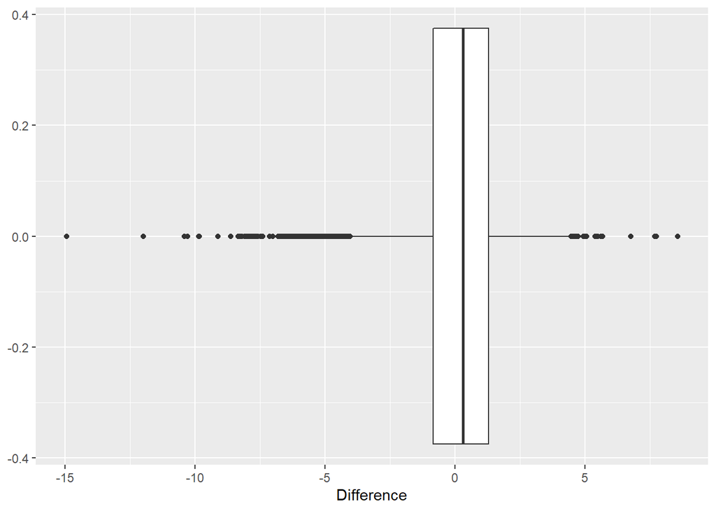

```r
ggplot(abalone_predict, aes(x=Difference)) + geom_boxplot()
```